# Using Text Mining Analysis to Make Suggestions to Improve the Rating of a Poorly-Rated Business

### 4.2 Exploratory Data Analysis

Looking at this, Geno’s Steaks is far away from the other steakhouses. So, theoretically they have the advantage of being less competition. However, the location of the other steakhouses seems to be nearer to a city hall and a main transportation route while Geno’s Steaks is comparatively out of the way.

[interactive chart not shown]

Aside from the month of 2019-07, the most popular period for reviews for this business occurred from around mid 2013 to late 2014. The colours correspond to the frequency, pink 0-10, orange 11-20, blue 21-30, yellow 31-40, black 41-50, red is 53.

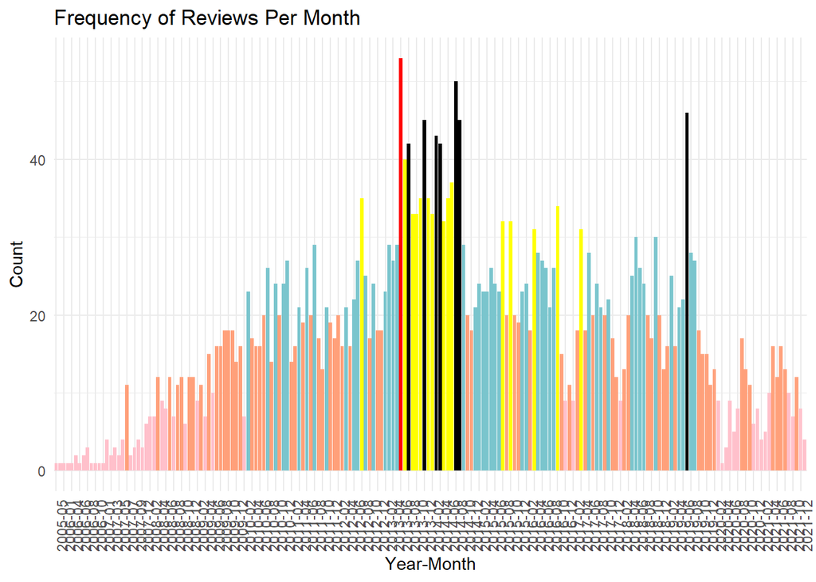

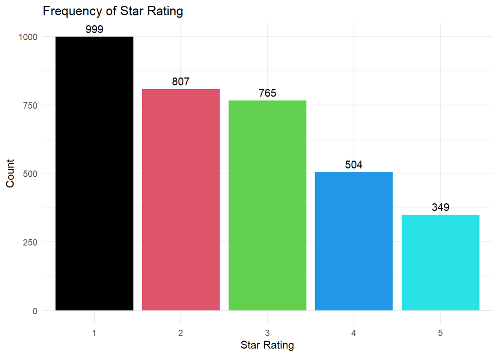

5-star reviews have always lagged behind the others, growing at a consistent rate. However, on the other hand, during the rush of reviews during 2013-2014 mentioned before, the rates of other star ratings went up with 1-star ratings going slightly more up compared to 2, 3, 4 rating.

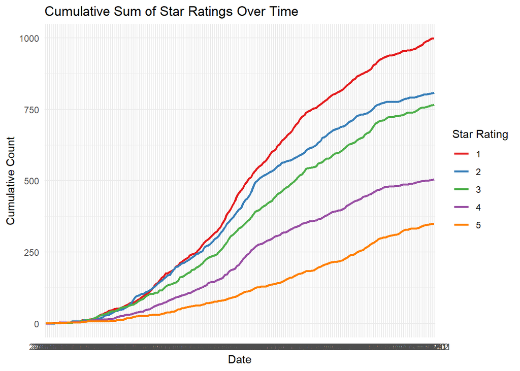

```r
df_cumsum <- gen_rev %>% mutate(review_month = format(gen_rev$yelp_review.date, "%Y-%m")) %>%
  count(review_month,yelp_review.stars) %>%
  pivot_wider(names_from = yelp_review.stars, values_from = n, values_fill = 0, names_prefix = "star_") %>%
  arrange(review_month) %>%
  mutate(across(starts_with("star_"), cumsum)) %>%
  pivot_longer(cols = starts_with("star_"),
               names_to = "star",
               names_prefix = "star_",
               values_to = "cum_count")%>% ungroup() %>% group_by(star) %>%
  mutate(star = factor(star), percent_cum = 100 * (cum_count / max(cum_count)))

#Cumulative sum of stra rating
ggplot(df_cumsum, aes(x = review_month, y = cum_count,color = star, group = star)) +
  geom_line(size = 1) +
  labs(
    title = "Cumulative Sum of Star Ratings Over Time",
    x = "Date",
    y = "Cumulative Count",
    color = "Star Rating"
  ) +
  scale_color_brewer(palette = "Set1") +
  theme_minimal()
```

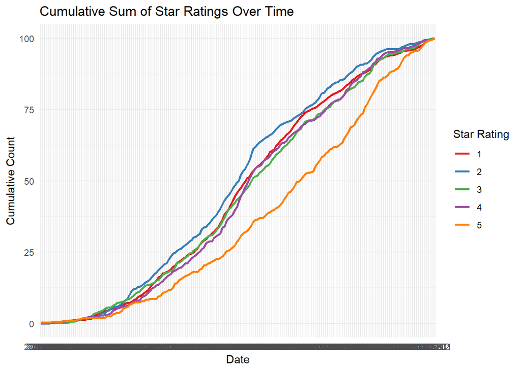

```r
#Percentage cumulative
ggplot(df_cumsum, aes(x = review_month, y = percent_cum,color = star, group = star)) +
  geom_line(size = 1) +
  labs(
    title = "Cumulative Sum of Star Ratings Over Time",
    x = "Date",
    y = "Cumulative Count",
    color = "Star Rating"
  ) +
  scale_color_brewer(palette = "Set1") +
  theme_minimal()
```

### 4.3 Analysis: Word Frequencies / Word Association

A Document-Term Matrix (DTM) is a table that represents the frequency of terms or words in our collection of reviews. Based on the DTM, there are 9022 unique words.

```r
library(tm)
dtm<-DocumentTermMatrix(docs)
dtm_df<-data.frame(cbind(as.matrix(dtm),gen_rev$yelp_review.stars))
names(dtm_df)[9023]<-"stars_rating"
dtm_df$stars_rating<-as.integer(dtm_df$stars_rating)

library(tidyverse)
#Frequency of words per star rating
d<-dtm_df %>% group_by(stars_rating) %>% summarise(across(everything(),sum)) %>% pivot_longer(cols = -stars_rating, names_to="term",values_to="freq")

#Frequency of words overall
dtm_sum<- data.frame(names(colSums(as.matrix(dtm))),colSums(as.matrix(dtm)))
names(dtm_sum)<-c("term","freq")
```

#### Term Frequency

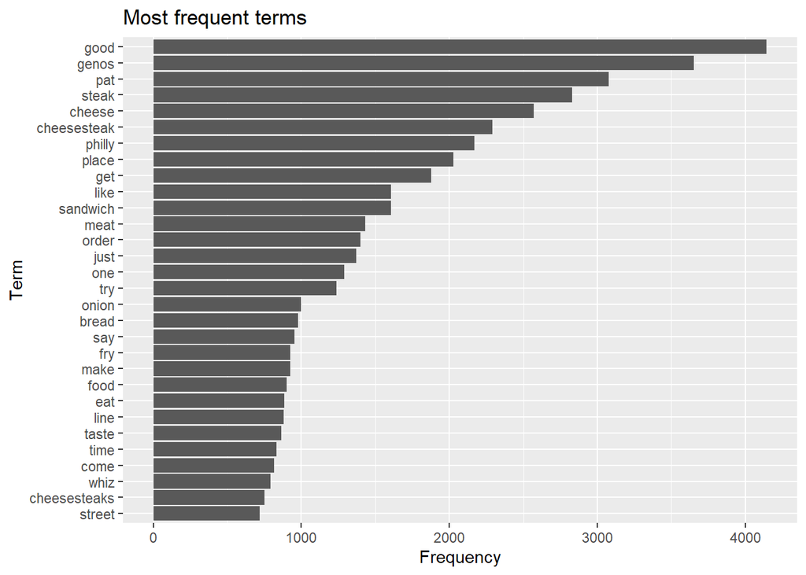

```r
dtm_sum %>% arrange(desc(freq)) %>% head(30) %>%
  ggplot(aes(x=freq, y=reorder(term,freq))) +
  geom_bar(stat="identity") +
  labs(
    title="Most frequent terms",
    y="Term",
    x="Frequency"
  )
```

#### Wordcloud

For words with a frequency of at least 200, the key words are most related to food or cooking terms (fry, provolone, onion), or the location (Philly), although there are less nicer words like ‘bad’, ‘bland’, ‘rude’, ‘disappoint’, and ‘trap’.

```r
library(wordcloud2)
wordcloud2(dtm_sum[dtm_sum$freq >=200,],size=0.7,shape="diamond",shuffle = FALSE)
```

[interactive chart not shown]

In order to capture the ‘unique’ words within a particular star rating, the percent frequency was calculated where the word has appeared at least 30 times over all reviews. Therefore, if a word has a higher frequency in 1-star reviews compared to other star reviews, it will have a higher proportion. For example, the word ‘disgust’ appears in 1-star reviews 88% percent of the time, making it more unique to that. Apart from negative descriptor words, other words that appear include xenophobic, tasteless, overpriced, rubbery, racist, racism, rude, flavorless, immigrant, stale.

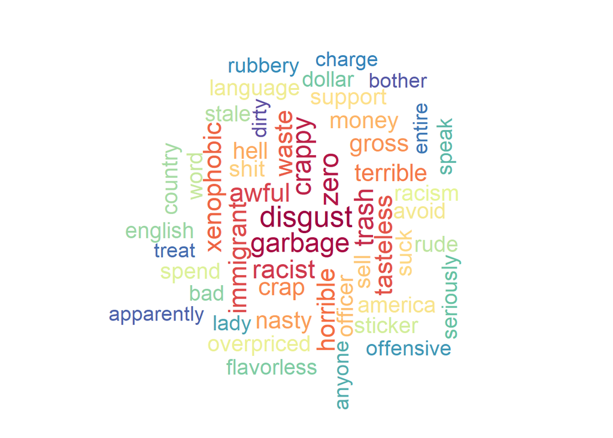

```r
library(wordcloud)
d2 <- d %>% group_by(term) %>%
  mutate(total = sum(freq)) %>%
  mutate(percent_freq = round((freq/total)*100)) %>%
     filter(total>=30) %>% slice_max(percent_freq, n = 1, with_ties = FALSE) %>% ungroup() %>% arrange(desc(percent_freq))
d3 <- d2 %>% filter(stars_rating == 1) %>% slice_head(n = 50)
wordcloud(
  words = d3$term,
  freq = d3$percent_freq,
  min.freq = 1,
  scale = c(2, 0.5),
  colors = colorRampPalette(brewer.pal(10, "Spectral"))(length(d3$term)),
  ordered.colors = T,
  random.order = FALSE,
  rot.per = 0.25
)
```

Moving to the 2-star reviews, additional problems are being complained about. Neon lights and food that is grease-y, cheap or soggy appear here. The word ‘toast’ comes from feedback about upsettingly untoasted bread.

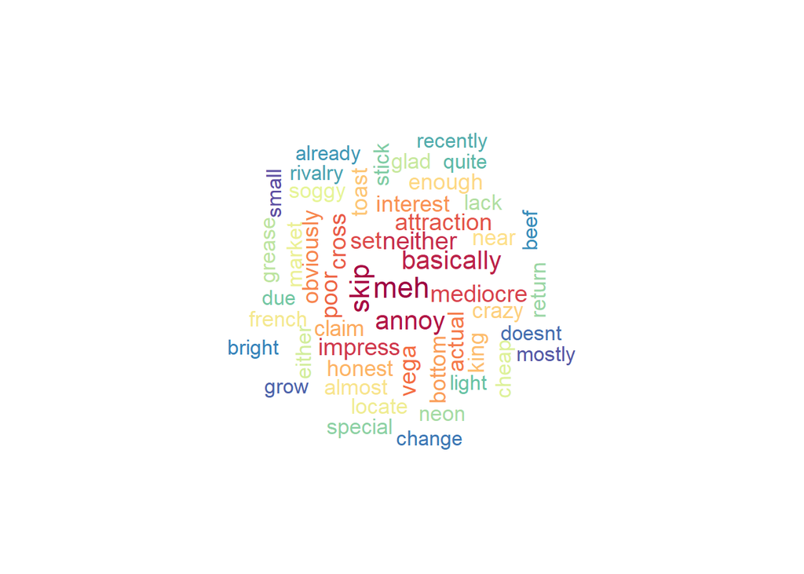

```r
d3 <- d2 %>% filter(stars_rating == 2) %>% slice_head(n = 50)
wordcloud(
  words = d3$term,
  freq = d3$percent_freq,
  min.freq = 1,
  scale = c(1.5, 0.5),
  colors = colorRampPalette(brewer.pal(10, "Spectral"))(length(d3$term)),
  ordered.colors = T,
  random.order = FALSE,
  rot.per = 0.25
)
```

For 3-star ratings, words that are predominantly in it are becoming more neutral.

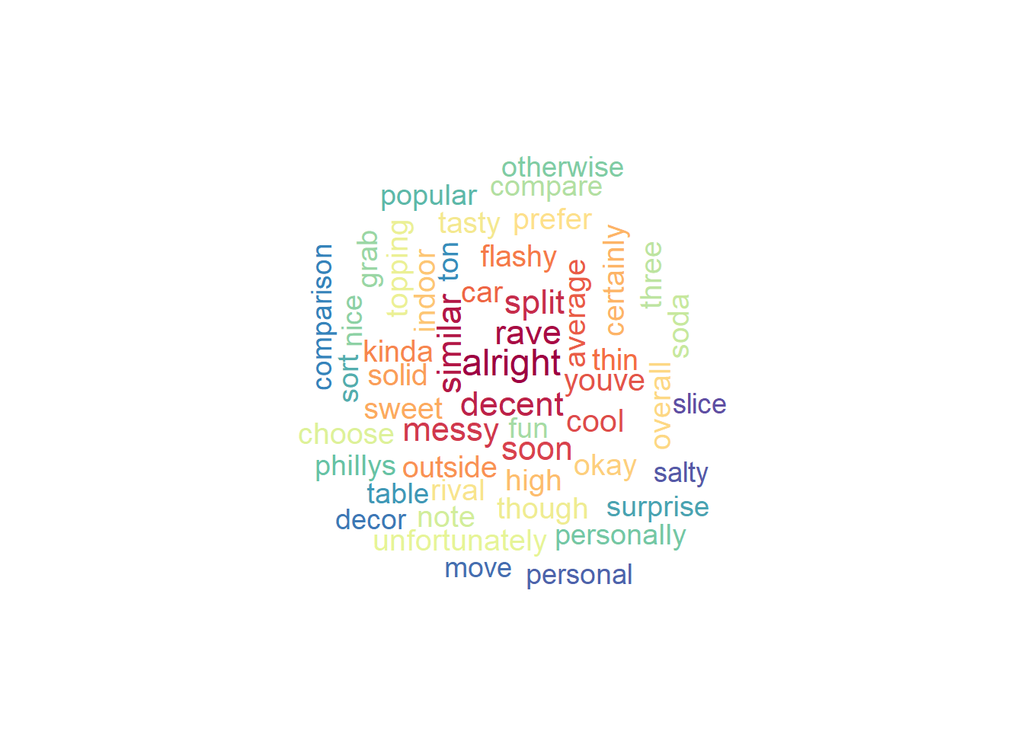

```r
d3 <- d2 %>% filter(stars_rating == 3) %>% slice_head(n = 50)
wordcloud(
  words = d3$term,
  freq = d3$percent_freq,
  min.freq = 1,
  scale = c(1.5, 0.5),
  colors = colorRampPalette(brewer.pal(10, "Spectral"))(length(d3$term)),
  ordered.colors = T,
  random.order = FALSE,
  rot.per = 0.25
)
```

While it may be lacking in some respects, those who enjoyed their time in Genos’ Steaks’ food is tender and a classic. The word ‘friendly’ also appears here.

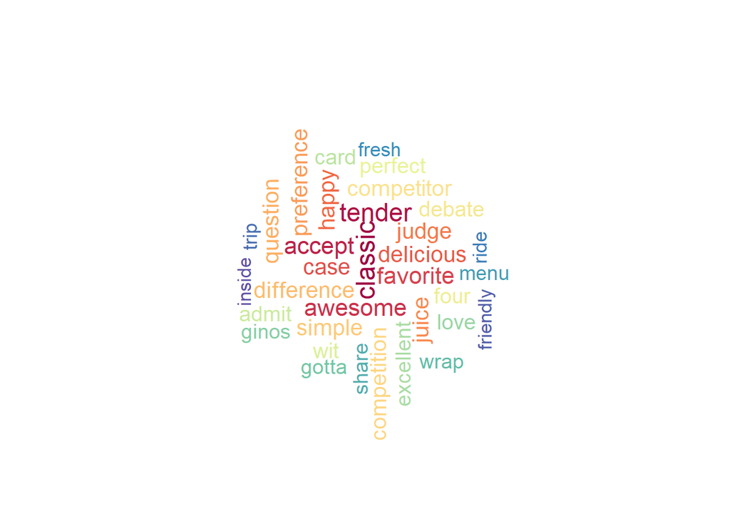

```r
d3 <- d2 %>% filter(stars_rating == 4) %>% slice_head(n = 50)
wordcloud(
  words = d3$term,
  freq = d3$percent_freq,
  min.freq = 1,
  scale = c(1.5, 0.5),
  colors = colorRampPalette(brewer.pal(10, "Spectral"))(length(d3$term)),
  ordered.colors = T,
  random.order = FALSE,
  rot.per = 0.25
)
```

For 5-star reviews, only 3 words are at 32, 30, and 26% out of the other star ratings appear. Which means there isn’t any term that is particularly unique in a 5 star rating that isn’t already appearing in a 4 star review or elsewhere.

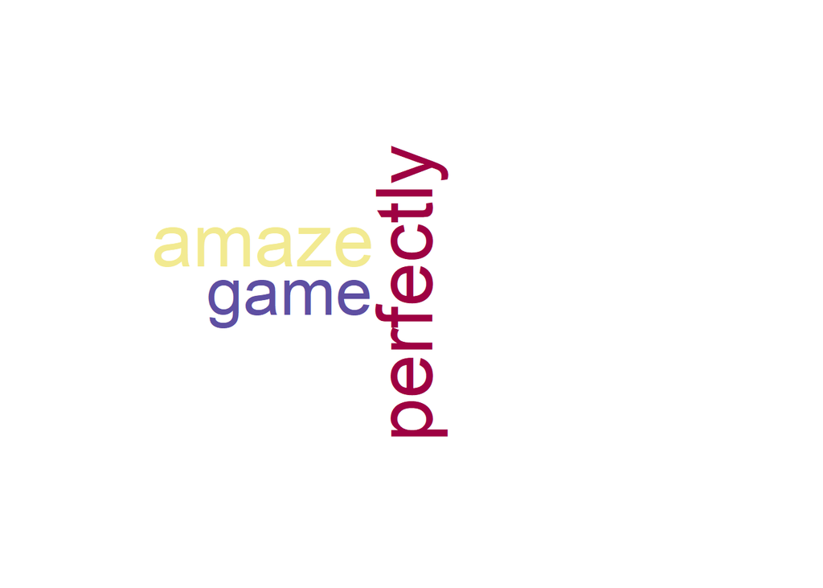

```r
d3 <- d2 %>% filter(stars_rating == 5) %>% slice_head(n = 50)
wordcloud(
  words = d3$term,
  freq = d3$percent_freq,
  min.freq = 1,
  colors = colorRampPalette(brewer.pal(10, "Spectral"))(length(d3$term)),
  ordered.colors = T,
  random.order = FALSE,
  rot.per = 0.25
)
```

#### Word Correlations

As can be seen below, the top three words are heavily associated with each other, with even ‘geno’ appearing in reviews often only when ‘pat’ is there too, most likely as a way to refer and differentiate them. While ‘genos’ is more or less associated with food items, the word ‘pat’ is often appears in reviews together with words like ‘compare’, ‘comparison’, ‘either’, ‘difference’, ‘prefer’, ‘decide’, which tracks with how it is often brought up in reviews as something reviewers measure Geno’s Steaks to.

```r
findAssocs(dtm,"good",0.2)
```

```
## $good
##       genos         pat         one cheesesteak        like      philly
##        0.31        0.31        0.25        0.24        0.23        0.23
##       steak       bread      cheese        make         get       order
##        0.23        0.22        0.22        0.22        0.22        0.21
##       place       think
##        0.21        0.21
```

```r
findAssocs(dtm,"genos",0.2)
```

```
## $genos
##          pat         good        steak  cheesesteak        order          one
##         0.64         0.31         0.31         0.30         0.30         0.29
##         meat       philly         also         make        onion         whiz
##         0.28         0.27         0.27         0.26         0.26         0.26
##          two          say          get       little     sandwich        bread
##         0.26         0.26         0.25         0.24         0.24         0.23
##         just         like          try         find        think       window
##         0.23         0.23         0.23         0.23         0.23         0.23
##        first philadelphia         bite       decide        slice       cheese
##         0.23         0.23         0.22         0.22         0.22         0.21
##      compare        right          eat          way       street         much
##         0.21         0.21         0.21         0.21         0.21         0.20
##       review         seem        since         chop
##         0.20         0.20         0.20         0.20
```

```r
findAssocs(dtm,"pat",0.2)
```

```
## $pat
##      genos       good        two    compare comparison       meat        one
##       0.64       0.31       0.27       0.25       0.25       0.24       0.24
##        try      steak     street       whiz     little      bread       seem
##       0.24       0.24       0.24       0.24       0.23       0.22       0.22
##     across     either       like      think difference      slice       chop
##       0.22       0.21       0.21       0.21       0.21       0.21       0.21
##     prefer     decide
##       0.21       0.20
```

Compared to the top 3 words, many of the negative words aren’t as heavily associated with another word, with those at a correlation limit of around 0.1 to 0.2 usually only matching one or two reviews. For words like ‘bad’, ‘rude’, and ‘disappoint’, it means those words are used generally. Exceptions are the word ‘trap’ with the word ‘tourist’, referring to the phrase ‘tourist trap’ to describe it. For ‘racist’ and ‘offensive’, both are associated with the word ‘sign’. The word ‘sign’ itself is also heavily associated with ‘english’, ‘speak’, ‘america’.

```r
findAssocs(dtm,"bad",0.15)
```

```
## $bad
##        ever politicsand        even  genosyoull      shaker
##        0.24        0.24        0.18        0.17        0.17
```

```r
findAssocs(dtm,"disappoint",0.15)
```

```
## $disappoint
## orderlike  meatball
##      0.17      0.16
```

```r
findAssocs(dtm,"rude",0.15)
```

```
## $rude
##     lady    staff    logic shitload
##     0.23     0.19     0.16     0.16
```

```r
findAssocs(dtm,"trap",0.15)
```

```
## $trap
##      tourist dellesandros pennsyltucky     gristled
##         0.55         0.18         0.18         0.18
```

```r
findAssocs(dtm,"offensive",0.20)
```

```
## $offensive
##           bolt   chicagostyle       construe      giordanos       interpet
##           0.33           0.33           0.33           0.33           0.33
##       malnatis        soapbox         speech        stellar           sign
##           0.33           0.33           0.26           0.24           0.23
##          flair discriminatory            lou      outwardly         belief
##           0.23           0.23           0.23           0.23           0.22
```

```r
findAssocs(dtm,"racist",0.20)
```

```
## $racist
##       sign      speak       race   religion      owner       bely   cesspool
##       0.26       0.26       0.26       0.26       0.25       0.25       0.25
##     doubly     errand      false     gender  horsecrap   runowned       tale
##       0.25       0.25       0.25       0.25       0.25       0.25       0.25
##   thatthen    reserve propaganda    english      bigot   ignorant management
##       0.25       0.24       0.23       0.23       0.22       0.22       0.22
```

```r
findAssocs(dtm,"sign",0.25)
```

```
## $sign
##   english     speak   america    parent   foreign   country  language   dialect
##      0.54      0.48      0.39      0.30      0.29      0.28      0.28      0.28
##    insert immigrate    racist
##      0.28      0.27      0.26
```

Unfortunately, specific words that could be associated with the food items could not be drawn. Many of these scores from just one review.

```r
findAssocs(dtm,"onion",0.25)
```

```
## $onion
##     order    cheese      whiz provolone     grill     genos  sandwich    remake
##      0.34      0.33      0.31      0.30      0.30      0.26      0.26      0.26
```

```r
findAssocs(dtm,"bread",0.2)
```

```
## $bread
##   meat   soft  chewy  genos  onion   good    pat cheese
##   0.32   0.26   0.23   0.23   0.23   0.22   0.22   0.21
```

```r
findAssocs(dtm,"toast",0.2)
```

```
## $toast
##     bleach      flour      olive indication     sponge
##       0.33       0.33       0.33       0.23       0.23
```

```r
findAssocs(dtm,"provolone",0.25)
```

```
## $provolone
## onion order  whiz
##  0.30  0.27  0.25
```

```r
findAssocs(dtm,"cheesesteak",0.25)
```

```
## $cheesesteak
##  genos philly  order    one    get
##   0.30   0.30   0.28   0.27   0.25
```

```r
findAssocs(dtm,"steak",0.25)
```

```
## $steak
##        cheese         genos         blasé   cheesegravy      creation
##          0.52          0.31          0.26          0.26          0.26
##    expedition        hunter       inhabit interestingly         kerry
##          0.26          0.26          0.26          0.26          0.26
##      montreal    possession     priscilla       procure   quasiracist
##          0.26          0.26          0.26          0.26          0.26
##           sam  scantilyclad  sequentially        skanky    steakeries
##          0.26          0.26          0.26          0.26          0.26
##         tammy    unmolested        uproar      vanessas
##          0.26          0.26          0.26          0.26
```

```r
findAssocs(dtm,"whiz",0.25)
```

```
## $whiz
##    cheese     onion     genos     order       wit provolone
##      0.35      0.31      0.26      0.26      0.26      0.25
```

```r
findAssocs(dtm,"flour",0.25)
```

```
## $flour
##       bleach        olive       sponge   complement     baguette unappetizing
##         1.00         1.00         0.71         0.58         0.45         0.41
##        toast      veggies  consistency        tooth
##         0.33         0.32         0.29         0.27
```

#### Bigram Network

Compared to the term frequency, using bigrams to analyse Yelp reviews for Genos seems to accrue more meaningful keyword expressions at a glance. Interestingly, a lot of the bigrams are to do with complaints when ignoring the common words like the food and location names. Reviewers seem to feel like Geno’s Steak is a tourist trap that is nothing special, or even worse, a waste of time since you might have to wait in line for a long time. It also highlights one major source of how people hear about this restaurant through the TV food network show.

```r
library(tidytext)
processed_text<- data.frame(text = docs, stringsAsFactors = FALSE)
gen_word_pairs_ori <- processed_text %>%
  unnest_tokens(bigram,text,token = "ngrams", n = 2) %>%
  count(bigram, sort = TRUE) %>% separate(bigram, c("word1", "word2"), sep = " ")
```

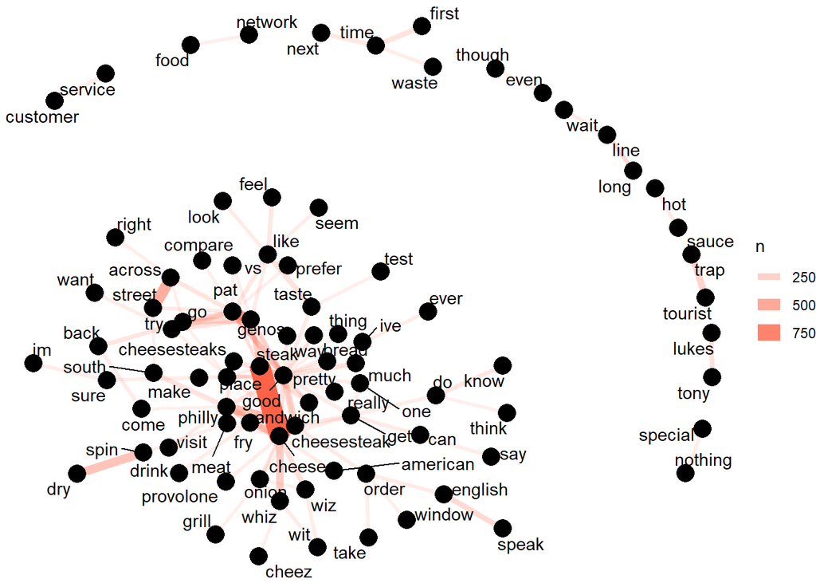

```r
library(igraph)
library(ggraph)
gen_word_pairs_ori %>%
  filter(n >= 50) %>%
  graph_from_data_frame() %>%
  ggraph(layout = "kk") +
  geom_edge_link(aes(edge_alpha = n, edge_width = n),  edge_colour = "tomato") +
  geom_node_point(size = 5) +
  geom_node_text(aes(label = name), repel = TRUE,
                 point.padding = unit(0.2, "lines")) +
  theme_void()
```

After removing six frequent terms, the network redrawn’s nodes are more visible, letting me lower the filter. Some were already apparent in the previous network like ‘spin dry’, a cooking technique. Other than that, typical common phrases like ‘pretty much’, ‘wasn’t bad’, ‘french fry’, ‘taste test’, ‘neon light’, ‘hot sauce’, ‘outdoor seat’, ‘somewhere else’, ‘fast service’, ‘lack flavour’. Other bigrams that are readily apparent to understanding include ‘joey vento’, the owner of Geno’s.

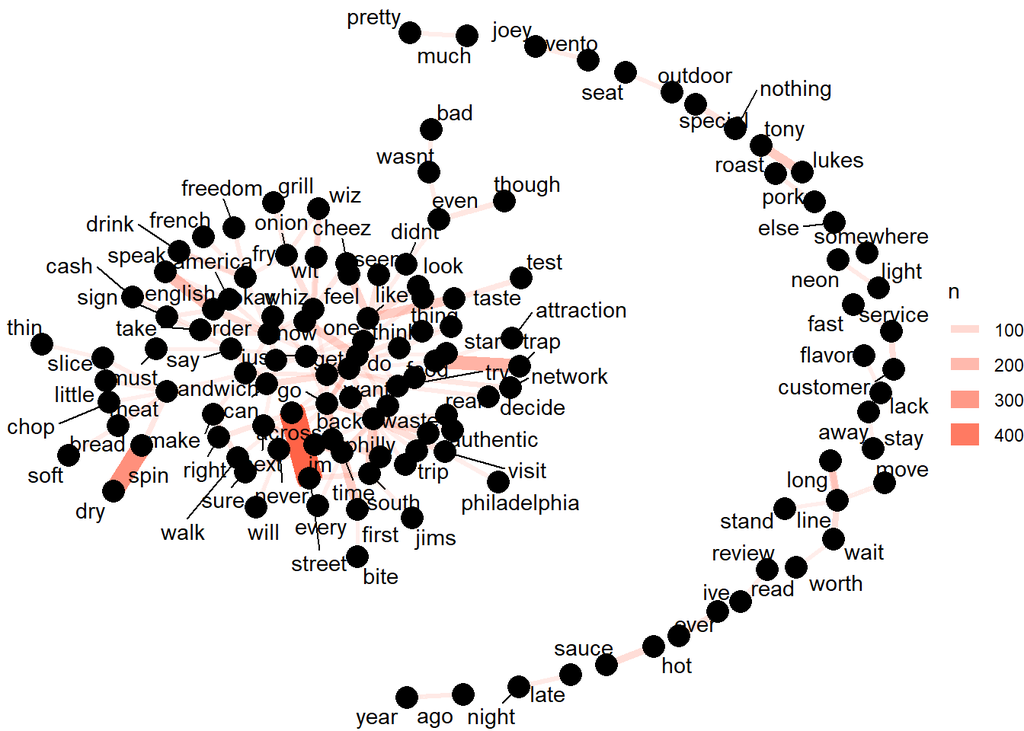

```r
common_words<-c("cheese","steak","genos","pat","cheesesteak","good")
gen_word_pairs <- processed_text %>%
  unnest_tokens(bigram,text,token = "ngrams", n = 2) %>%
  separate(bigram, c("word1", "word2"), sep = " ") %>%
  filter(!word1 %in% common_words,
         !word2 %in% common_words) %>%
  unite(bigram, word1, word2, sep = " ") %>%
  count(bigram, sort = TRUE) %>% separate(bigram, c("word1", "word2"), sep = " ")
gen_word_pairs %>%
  filter(n >= 30) %>% #change this
  graph_from_data_frame() %>%
  ggraph(layout = "kk") +
  geom_edge_link(aes(edge_alpha = n, edge_width = n),  edge_colour = "tomato") +
  geom_node_point(size = 5) +
  geom_node_text(aes(label = name), repel = TRUE,
                 point.padding = unit(0.2, "lines")) +
  theme_void()
```

### 4.4 Analysis: Sentiment Analysis

#### Pre-processing

```r
library(syuzhet)
library(tidyverse)
sen<-as.data.frame(cbind(gen_rev, syuzhet = get_sentiment(docs, method="syuzhet"),
                         bing = get_sentiment(docs, method="bing"),
                         afinn = get_sentiment(docs, method="afinn"),
                         nrc = get_sentiment(docs, method="nrc"),get_nrc_sentiment(docs)))
```

#### Exploratory data analysis

All of them are distributed around the same range. Any slight differences depends on how prolific each sentiment method’s dictionary of words is and their scoring scale. For example, AFINN is between -5 to 5 so its x-axis has a much wider range compared to a smaller scoring scale like Bing’s.

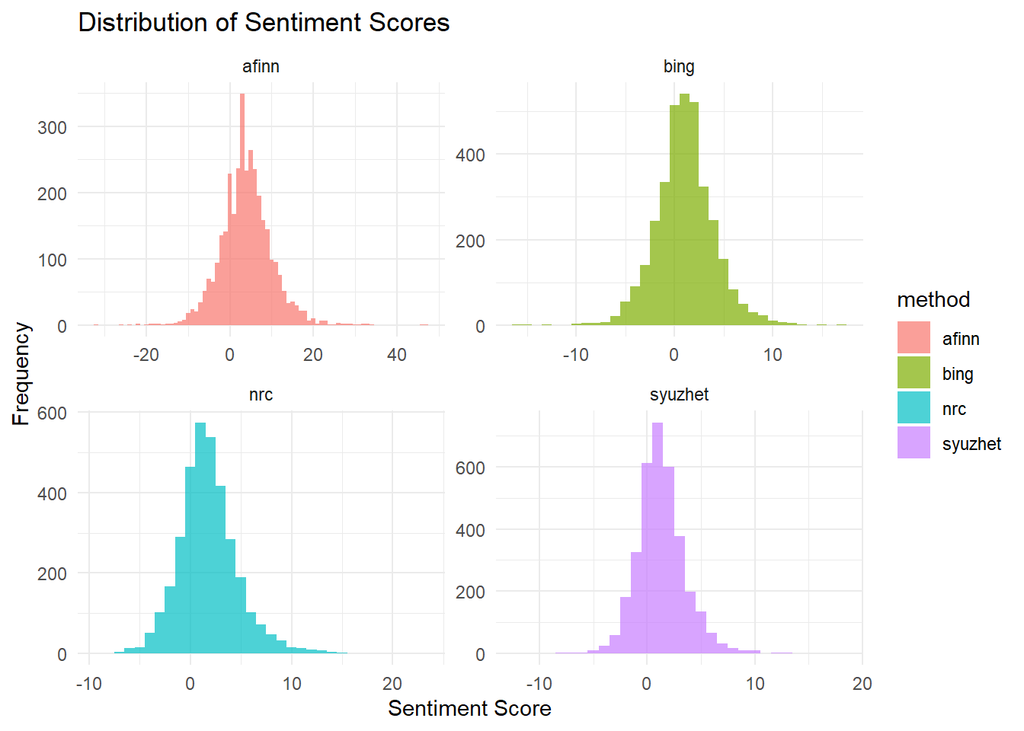

```r
sen %>%
  pivot_longer(cols = c("syuzhet","bing", "afinn", "nrc"), names_to = "method", values_to = "score") %>%
  ggplot(aes(x = score, fill = method)) +
  geom_histogram(binwidth = 1, alpha = 0.7, position = "identity") +
  facet_wrap(~ method, scales = "free") +
  theme_minimal() +
  labs(title = "Distribution of Sentiment Scores", x = "Sentiment Score", y = "Frequency")
```

#### Emotions Per Star Rating

Below is a radar chart which shows the variation per star rating for each of the emotions. Red, orange, blue, yellow, purple correspond to 1-, 2-, 3-, 4-, and 5-star ratings respectively. The scales are normalized by binding it in between each rating’s maximum value so it can be directly plotted and shown on the same radar chart. Each polygon represents the relative emotion score per star rating. The largest difference is between 1-star reviews and then 3-, 4-, 5-star reviews. For the negative emotions, 1 has comparativly higher numbers of words related to disgust, anger, fear and sadness compared to 3, 4, 5, while 2 is approximately the midpoint. Positive emotions for 3, 4, 5, don’t look too dissimilar.

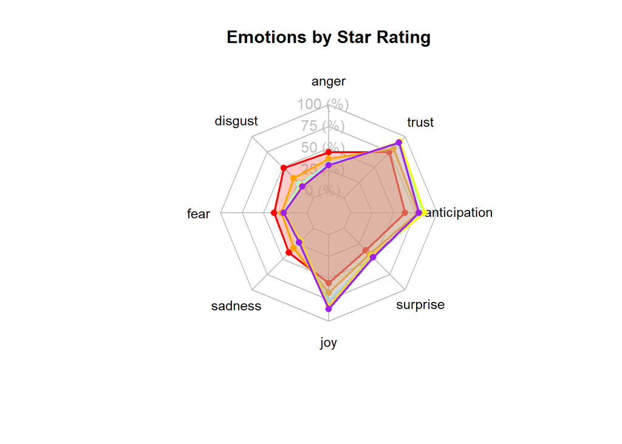

```r
library(fmsb)
emo_per_star <- sen %>%
  group_by(yelp_review.stars) %>%
  summarise(across(c(anger, disgust, fear, sadness, joy, surprise, anticipation, trust), sum, .names = "{.col}")) %>% rowwise() %>%
  mutate(total = sum(c_across(anger:trust))) %>%
  mutate(across(anger:trust, ~ .x / total * 100)) %>%
  ungroup() %>%
  select(-total) %>%
  arrange(yelp_review.stars)
rr <- rbind(rep(25,8), rep(0, 8), emo_per_star[,-1])
rownames(rr) <- c("Max", "Min", paste0("Star ", emo_per_star$yelp_review.stars))

radarchart(
  rr,
  axistype = 1,
  pcol =  c("red", "orange", "darkslategray1","yellow", "purple"),
  pfcol = adjustcolor( c("red", "orange", "darkslategray1","yellow", "purple"), alpha.f = 0.2),
  plwd = 2,
  plty = 1,
  cglcol = "grey",
  cglty = 1,
  axislabcol = "grey",
  vlcex = 0.9,
  title = "Emotions by Star Rating"
)
```

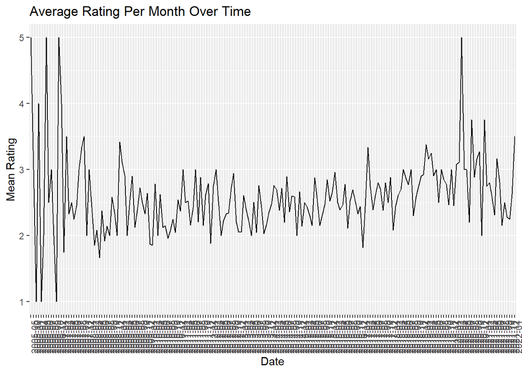

```r
sen %>% mutate(review_month = format(gen_rev$yelp_review.date, "%Y-%m")) %>%
  group_by(review_month) %>%
    summarise(
    avg_star = mean(yelp_review.stars, na.rm = TRUE),
    review_count = n()
  ) %>%
  ggplot(aes(x = review_month, y = avg_star, group = 1)) +
  geom_line() +
   theme(axis.text.x = element_text(angle = 90, hjust = 1)) +
  labs(title = "Average Rating Per Month Over Time", x = "Date", y = "Mean Rating")
```

## 5.0 Discussion and Recommendations

The Yelp dataset is a massive file with the review.json being 5GB by itself; this makes it extremely difficult or limiting to handle in a software like R which defaults to handling objects in its environment in RAM. This is one of the reasons what makes Yelp a suitable dataset to have to load into a Hadoop ecosystem. In this assignment, putting it in Hive lets us easily query and subset the tables we need directly.

After looking at the dataset overall using SQL to query various characteristics, Geno’s Steaks was zeroed in on due to its very low rating compared to the similar Philadelphian steakhouse restaurants in the same area despite having very high number of reviews. This makes it a welcome candidate to text analysis to process and handle it. Overall, text mining analysis can be an effective way to process and visualise thousands of lines of text in an informative way, limiting the need for manual reading and examination. of all reviews. In addition, it allows quantitatively words against each other for comparison.

For pinpointing reviews that mention or identify areas of improvement, using a mix of different techniques of text analysis helps provide a fuller image. Techniques done in this small assignment was term frequency, word pairs, word correlations that could help find keywords.

Term frequency lets us see and compare what terms appear frequently across all the reviews. Looking at it overall, most of the common words was related to the business or to the food items; it wasn’t very helpful for the objective of finding areas of improvement. However, once it was narrowed to term frequencies per star rating, a clearer picture began to form. Initially, I hoped to find unique words for 5-star ratings as feedback for what the business should continue doing, however, there was none. The most common words for 5-star reviews were the most common words in general. Conversely, the lower-star ratings, especially the 1-star reviews had cited issues such as ‘rubbery’ meat, ‘stale’ and ‘tasteless’ food. The most significant issue and the most prominent complaint for this business is related to perceived discriminatory, xenophobic messaging, namely, a hotly mentioned issue is a sign to the tone of, paraphrased, ‘To speak english, this is America’. If the business is ever concerned about improving its rating on Yelp, resolving that would be key. Apart from the usual improvement that could be made to any food place like better food quality, and customer service, another minor issue is the glaring neon lights. Overall, using term frequency was a very effective way to narrow down keywords related to customer grievances; however, the issue with using term frequency is that it removes all context. If a word such as ‘friendly’ pops up a lot, it would be initially difficult to determine if that is meant to be a good thing or a bad thing (e.g. ‘not friendly’). Both ‘friendly’ and ‘not friendly’ would count towards the same. Another example is the word ‘trash’ appearing in the 1-star rating wordcloud. At first glance, it could be a complaint about a messy restaurant, but ‘trash’ can also appear as an adjective (‘this is trash’) or a verb (‘my friends always trash this place to me’), so finding the original review is paramount. Finally, wordcloud was used to colourfully communicate the frequency using size and colour to denote it, however its output can be variable. Based on that, it’s a nice overview, but not good for strict conveyance of data.

Talking about context, word associations or word correlations examine statistical relationships between words in a document. Words that appear together frequently are said to have high correlation. While great in theory, using in this context was difficult and many of the correlations simply came from just one or two review mentioning together. Some words would have the same level of correlation but differ in the number of reviews that actually mention them together, so it impossible to directly tell how many evidence there is. Also, in general, most of the associations were very, very weak. Making recommendations for improvement based on word correlations is of limited use. However, word associations highlighted an intense rivalry between two steakhouses with many of the reviews driven to comparing the two. In addition, using word correlations together with term frequency allowed me identify the existence of the restaurant’s signage that fueled the unique words in the 1-star wordcloud.

Bigrams is similar to term frequency except instead of counting frequency of just one word, it counts up the frequencies of pairs of words. It provides slightly more context. Using this and adjusting the bigram network, re-occuring words that appear adjacent to each other as appear as a pattern. Projecting this method to a network graph allows connections between words to be clearly illustrated like how common words ‘line’ is connected to ‘wait’, ‘and’, ‘move’, ‘long’, ‘wait’, but the ‘wait’ is ‘worth’ it which is also connected to ‘definitely’ (not seen here). Compared to word associations, bigrams better capture a local space, but it also means there is some superfluous bigrams that reflect the english language’s phrasing rather than something something specific to the dataset. Recommendations based on bigrams aren’t many, in fact, this is the only method that finally drew some positive feedback which is that they have ‘fast service’.

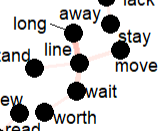

Recommendations to further improve insight into this include doing sentiment analysis beyond just profiling the emotions associated a certain rating.

### Literature

When comparing wordclouds, many of the words in the 1-star wordcloud and the general overall wordcloud match the top 20 negative words in Las Vegas, Nevada; words such as overpriced, soggy, rude, grease, and bland but at least Geno’s Steaks isn’t associated with ‘closed’ or ‘dirty’ or ‘slow’, or ‘overcooked’ (based the negative word clouds for Charlotte and Pittsburgh) (Wang and Qiu (2015)).

In other locations, 5-star reviews for quick server restaurants would be related to the cleanliness of the business or the how friendly the staff have been (Gadidov and Priestley (2018)). While there are some reviews in our dataset mentioning that, it’s not a major theme. For staff, some reviews for Geno’s Steaks mention friendliness and some are more mixed or even stated to be downright rude.

Another paper that looks into also corroborates that the average review for a user is very low, the majority being under 5 reviews. This could be a factor why the average number of business is very low, most people do not think to review every place they go to and only certain circumstances like providing negative feedback may be driving them to comment. For their wordcloud, it is for Gordon Ramsey’s BurGR. Their positive wordcloud has terms related to the food items and positive descriptors; the negative wordcloud has words like ‘waste’, ‘raw’, ‘nobody’ (Alamoudi and Al Azwari (2021)). In general, very similar to the term frequencies for Genos’ Steaks 1-star and 5-star.

## References

Alamoudi, Eman, and Sana Al Azwari. 2021. “Exploratory Data Analysis and Data Mining on Yelp Restaurant Review.” In, 1–6. https://doi.org/10.1109/NCCC49330.2021.9428850.

Gadidov, Bogdan, and Jennifer Lewis Priestley. 2018. “Does Yelp Matter? Analyzing (And Guide to Using) Ratings for a Quick Serve Restaurant Chain.” In *Guide to Big Data Applications*, edited by S. Srinivasan, 503–22. Cham: Springer International Publishing. https://doi.org/10.1007/978-3-319-53817-4_19.

Wang, Mingshan, and Rui Qiu. 2015. “Text Mining for Yelp Dataset Challenge.” In. https://api.semanticscholar.org/CorpusID:41546427.

Yelp. n.d. “Yelp Open Dataset.” https://business.yelp.com/data/resources/open-dataset/.